# **Evaluación de modelos para la predicción semanal de accidentes viales con Gravedad: Solo Daños**

Alexis A. Arenas Bustamante, Juan E. Arroyave Duque, William A. Jovel Tamayo, Manuela Londoño Ocampo.* Curso de Analítica Predictiva Universidad Nacional de Colombia Facultad de Minas Medellín

Septiembre de 2019

# 1 **Librerías Necesarias**

```r
knitr::opts_chunk$set(echo = TRUE)
library(dplyr) # data wrangling
library(ranger)
library(caret)
library(corrplot)
library(rsample)     # data splitting
library(rpart)       # performing regression trees
library(rpart.plot)  # plotting regression trees
library(ipred)       # bagging
require(MASS)
library(randomForest)
library(tidyverse)
library(ggpubr)
```

Se consideran tres modelos para la predicción semanal de los accidentes viales con solo daños: Regresión lineal, Árbol de regresión y Random Forest. A continuación se presenta la evaluación de cada uno:

# 2 **Dataset propuesto para el modelo semanal de accidentalidad vial : Solo daños**

|  | SOLO_DANOS | ANYO | SEMANA | FESTIVOS | SEMANA_SANTA | COLOMBIAMODA | FERIA_FLORES | ENERO_1 | PUENTE_REYES | DIC_31 | DIC_24 |
| --- | --- | --- | --- | --- | --- | --- | --- | --- | --- | --- | --- |
| 1 | 18 | 1 | 1 | 1 | 0 | 0 | 0 | 1 | 0 | 0 | 0 |
| 2 | 16 | 1 | 1 | 1 | 0 | 0 | 0 | 0 | 1 | 0 | 0 |
| 3 | 180 | 1 | 1 | 0 | 0 | 0 | 0 | 0 | 0 | 0 | 0 |
| 4 | 294 | 1 | 2 | 0 | 0 | 0 | 0 | 0 | 0 | 0 | 0 |
| 5 | 347 | 1 | 3 | 0 | 0 | 0 | 0 | 0 | 0 | 0 | 0 |
| 6 | 378 | 1 | 4 | 0 | 0 | 0 | 0 | 0 | 0 | 0 | 0 |

# 3 **Estadísticas Descriptivas**

## 3.1 **Summary del conjunto de datos**

```
##    SOLO_DANOS         ANYO           SEMANA         FESTIVOS
##  Min.   :  6.0   Min.   :1.000   Min.   : 1.00   Min.   :0.0000
##  1st Qu.: 42.0   1st Qu.:2.000   1st Qu.:15.00   1st Qu.:0.0000
##  Median :332.0   Median :3.000   Median :28.00   Median :0.0000
##  Mean   :255.7   Mean   :2.992   Mean   :27.34   Mean   :0.2308
##  3rd Qu.:383.0   3rd Qu.:4.000   3rd Qu.:41.00   3rd Qu.:0.0000
##  Max.   :477.0   Max.   :5.000   Max.   :53.00   Max.   :1.0000
##   SEMANA_SANTA      COLOMBIAMODA      FERIA_FLORES        ENERO_1
##  Min.   :0.00000   Min.   :0.00000   Min.   :0.00000   Min.   :0.00000
##  1st Qu.:0.00000   1st Qu.:0.00000   1st Qu.:0.00000   1st Qu.:0.00000
##  Median :0.00000   Median :0.00000   Median :0.00000   Median :0.00000
##  Mean   :0.03183   Mean   :0.01857   Mean   :0.03714   Mean   :0.01326
##  3rd Qu.:0.00000   3rd Qu.:0.00000   3rd Qu.:0.00000   3rd Qu.:0.00000
##  Max.   :1.00000   Max.   :1.00000   Max.   :1.00000   Max.   :1.00000
##   PUENTE_REYES         DIC_31            DIC_24
##  Min.   :0.00000   Min.   :0.00000   Min.   :0.00000
##  1st Qu.:0.00000   1st Qu.:0.00000   1st Qu.:0.00000
##  Median :0.00000   Median :0.00000   Median :0.00000
##  Mean   :0.01326   Mean   :0.01326   Mean   :0.01326
##  3rd Qu.:0.00000   3rd Qu.:0.00000   3rd Qu.:0.00000
##  Max.   :1.00000   Max.   :1.00000   Max.   :1.00000
```

## 3.2 **Histograma de la variable dependiente**

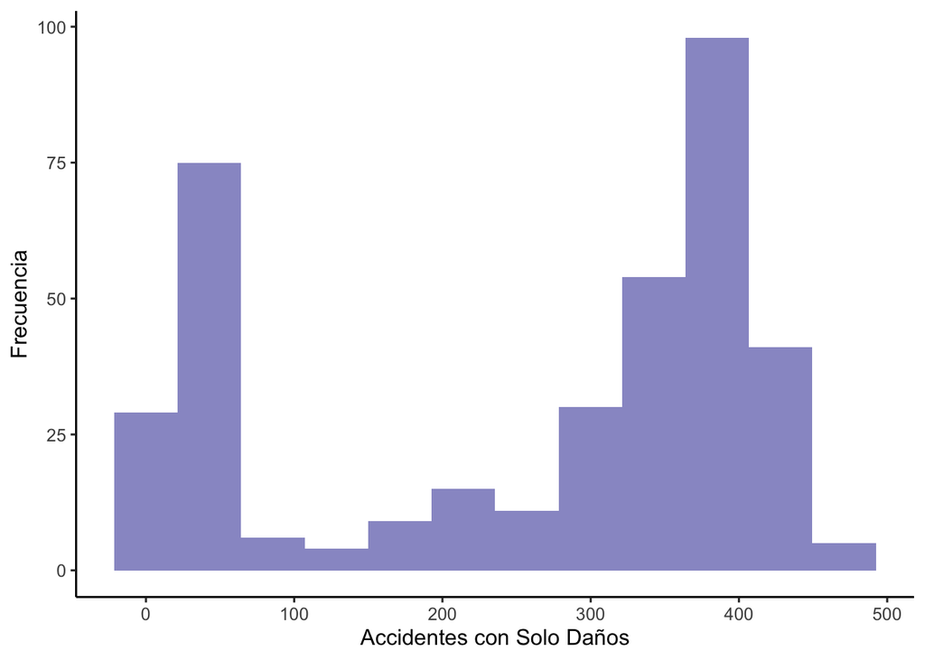

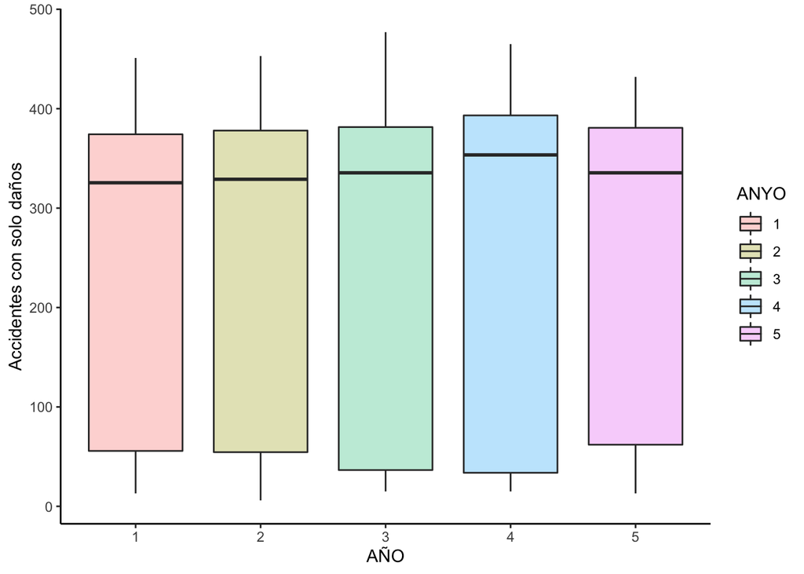

No se observan valores atípicos.

## 3.4 **Correlación entre variables consideradas**

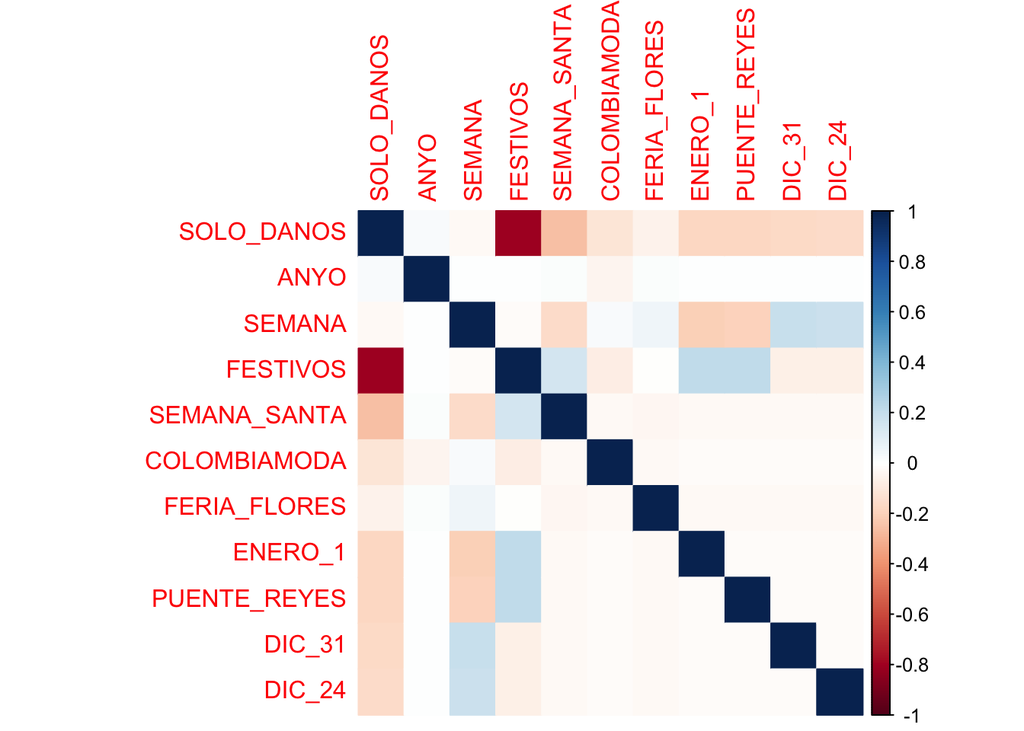

Se puede observar que la variable mas correlacionada con la cantidad de accidentes semanales con solo daños es FESTIVOS. En cada uno de los modelos se identificará la importancia de las variables, de modo que solo se incluyan aquellas que tengan una influencia significativa sobre la variables dependiente. El periodo no hará parte de ningún modelo puesto que solo se usa para la partición de los datos en conjuntos de entrenamiento y validación.

# 4 **Partición de los datos conjuntos de train y test**

Para la validación se usaran los datos de accidentes viales ocurridos en el año 2018.

Datos de Train: Se cuenta 303 observaciones para el entrenamiento de los modelos

```
## [1] 303  11
```

Datos de Test: Se cuenta con 74 observaciones para la validación de los modelos

```
## [1] 74 11
```

Una vez realizada la partición de los datos, se procede con la eliminación de la variable ANYO en ambos datasets.

```r
soloD_train <- dplyr :: select(soloD_train, -ANYO)
soloD_test <- dplyr :: select(soloD_test, -ANYO)
```

# 5 **Modelo de predicción considerados**

## 5.1 **Regresión Lineal**

**Entrenamiento del modelo**

```r
soloD_train$SEMANA <- as.factor(soloD_train$SEMANA)
regresion_1 <- lm(SOLO_DANOS ~ ., data= soloD_train)
summary(regresion_1)
```

```
##
## Call:
## lm(formula = SOLO_DANOS ~ ., data = soloD_train)
##
## Residuals:
##     Min      1Q  Median      3Q     Max
## -194.50  -24.22   -2.25   27.25  141.62
##
## Coefficients:
##              Estimate Std. Error t value Pr(>|t|)
## (Intercept)   201.830     27.457   7.351 3.02e-12 ***
## SEMANA2        49.091     35.633   1.378 0.169573
## SEMANA3       140.420     40.334   3.481 0.000592 ***
## SEMANA4       158.170     40.334   3.922 0.000115 ***
## SEMANA5       155.420     40.334   3.853 0.000149 ***
## SEMANA6       180.170     40.334   4.467 1.22e-05 ***
## SEMANA7       200.920     40.334   4.981 1.20e-06 ***
## SEMANA8       170.170     40.334   4.219 3.47e-05 ***
## SEMANA9       179.670     40.334   4.455 1.28e-05 ***
## SEMANA10      194.670     40.334   4.826 2.46e-06 ***
## SEMANA11      193.420     40.334   4.796 2.84e-06 ***
## SEMANA12      117.406     34.250   3.428 0.000715 ***
## SEMANA13      117.157     36.011   3.253 0.001303 **
## SEMANA14      119.564     37.315   3.204 0.001537 **
## SEMANA15      118.351     35.058   3.376 0.000857 ***
## SEMANA16      121.501     36.703   3.310 0.001074 **
## SEMANA17      208.920     40.334   5.180 4.68e-07 ***
## SEMANA18      121.941     34.849   3.499 0.000556 ***
## SEMANA19      178.479     38.159   4.677 4.84e-06 ***
## SEMANA20      168.279     38.159   4.410 1.56e-05 ***
## SEMANA21      176.920     40.334   4.386 1.72e-05 ***
## SEMANA22      118.545     35.643   3.326 0.001018 **
## SEMANA23      129.851     36.696   3.539 0.000482 ***
## SEMANA24      150.479     38.159   3.944 0.000105 ***
## SEMANA25      125.351     36.696   3.416 0.000745 ***
## SEMANA26      115.184     36.696   3.139 0.001906 **
## SEMANA27      123.518     36.696   3.366 0.000887 ***
## SEMANA28      168.420     40.334   4.176 4.15e-05 ***
## SEMANA29      100.253     34.257   2.927 0.003754 **
## SEMANA30       29.321     36.863   0.795 0.427168
```

[output cut: 22 more lines]

```
## SEMANA53     -149.830     65.158  -2.299 0.022330 *
## FESTIVOS     -280.542      9.825 -28.554  < 2e-16 ***
## SEMANA_SANTA -119.410     22.940  -5.205 4.13e-07 ***
## COLOMBIAMODA -129.578     30.756  -4.213 3.56e-05 ***
## FERIA_FLORES   31.963     27.447   1.165 0.245355
## ENERO_1        94.462     41.513   2.275 0.023752 *
## PUENTE_REYES   57.394     38.539   1.489 0.137728
## DIC_31        -25.500     66.065  -0.386 0.699849
## DIC_24       -227.271     36.517  -6.224 2.12e-09 ***
## ---
## Signif. codes:  0 '***' 0.001 '**' 0.01 '*' 0.05 '.' 0.1 ' ' 1
##
## Residual standard error: 59.09 on 242 degrees of freedom
## Multiple R-squared:  0.8872, Adjusted R-squared:  0.8593
## F-statistic: 31.73 on 60 and 242 DF,  p-value: < 2.2e-16
```

Las variable de SEMANA se incluyó en el modelo de regresión lineal como factor, vemos que la mayoría de variables son significativas para el modelo y según el summary se tiene un buen R-squared, que explica el 88.72 % de la accidentalidad semanal con gravedad de solo daños. De igual manera el valor P del estadístico F también es significativo.

**Métricas de Bondad para regresión lineal**

| RMSE_Train | Rsquared_Train | RMSE_Test | Rsquared_Test |
| --- | --- | --- | --- |
| 52.80851 | 0.8872277 | 53.19883 | 0.8779332 |

Comparando las métricas consideradas tanto para el entrenamiento como para la validación del modelo, observamos que en ambos se obtiene un R-squared bueno, superior al 85%. Adicionalmente la variación entre los RMSE es del 0,73 %, que indica un buen ajuste para ambos conjuntos de datos.

**Ajuste de las predicciones vs valores reales**

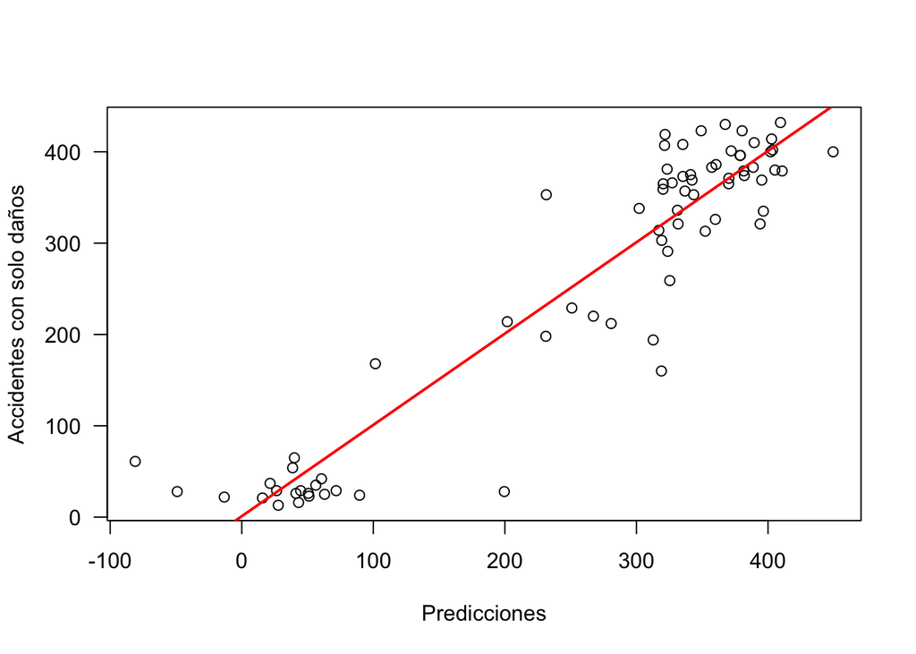

```r
plot(y_pred_test_sd, soloD_test$SOLO_DANOS,las=1, xlab="Predicciones", ylab = "Accidentes con solo daños")
abline(a=1,b=1,lwd=2,col="red")
```

En el gráfico de dispersión se puede observar que el modelo tiene mejor capacidad de predicción para valores de accidentalidad bajos pero no tanto para valores altos.

## 5.2 **Árbol Regresor**

**Entrenamiento del modelo**

Se toma el modelo mas simple para el árbol regresor, a partir de este se realizara una búsqueda tipo **grid search**, de los parámetros de restricción óptimos. Se definen ademas funciones para extraer el mínimo error asociado con el valor óptimo de costo de complejidad (CP) de cada modelo y el valor óptimo CP.

```r
set.seed(123)
dt_sd <- rpart(
  formula = SOLO_DANOS ~ .,
  data    = soloD_train,
  method  = "anova"
  )
```

**Representación gráfica del árbol regresor sin tuning**

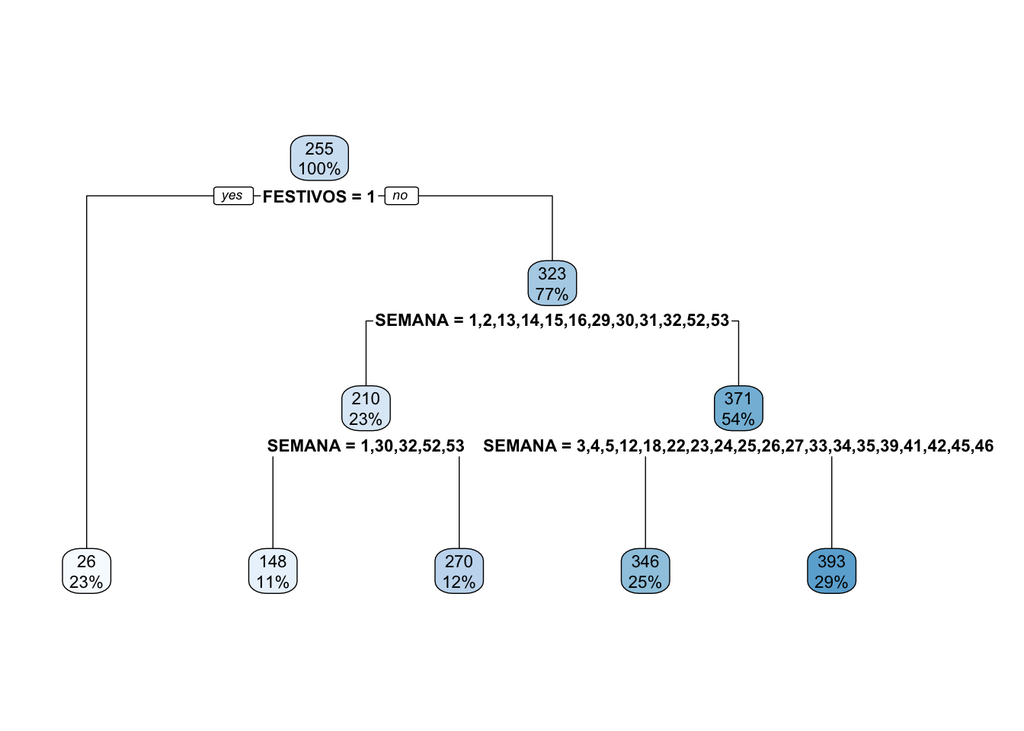

**Ajuste de parámetro de restricción para el árbol regresor**

Se realiza una búsqueda de los parámetros óptimos de minsplit y maxdepth para el árbol regresor:

En la siguiente gráfica se puede observar el numero optimo de nodos identificado por el modelo que reduce el error asociado. Este sera el punto de partida para definir entre que valores puede variar el parámetro de profundidad del árbol. Vemos que este valor es de 4 divisiones y 5 nodos finales.

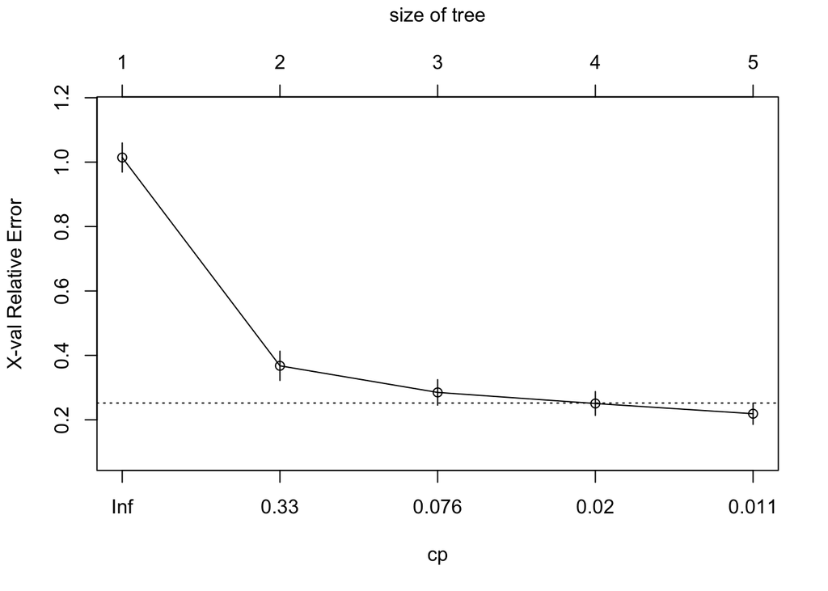

```r
plotcp(dt_sd)
```

```r
dt_sd2 <- rpart(
    formula = SOLO_DANOS ~ .,
    data    = soloD_train,
    method  = "anova",
    control = list(cp = 0, xval = 10)
)
```

```
##           CP nsplit rel error    xerror       xstd
## 1 0.63769714      0 1.0000000 1.0143602 0.04519058
## 2 0.16728224      1 0.3623029 0.3676612 0.04543587
## 3 0.03426709      2 0.1950206 0.2850301 0.03967854
## 4 0.01203826      3 0.1607535 0.2506045 0.03696938
## 5 0.01000000      4 0.1487153 0.2188883 0.03316713
```

El siguiente código define una función grid para la búsqueda de diferentes combinaciones de minsplit y maxdepth. También las funciones que extraen el optimo cp y el mínimo error asociado.

```r
hyper_grid_sd <- expand.grid(
  minsplit = seq(2, 20, 1),
  maxdepth = seq(2, 30, 1)
)
models_sd <- list()

for (i in 1:nrow(hyper_grid_sd)) {

  # get minsplit, maxdepth values at row i
  minsplit <- hyper_grid_sd$minsplit[i]
  maxdepth <- hyper_grid_sd$maxdepth[i]

  # train a model and store in the list
  models_sd[[i]] <- rpart(
    formula = SOLO_DANOS ~ .,
    data    = soloD_train,
    method  = "anova",
    control = list(minsplit = minsplit, maxdepth = maxdepth)
    )
}

# function to get optimal cp
get_cp <- function(x) {
  min    <- which.min(x$cptable[, "xerror"])
  cp <- x$cptable[min, "CP"]
}

# function to get minimum error
get_min_error <- function(x) {
  min    <- which.min(x$cptable[, "xerror"])
  xerror <- x$cptable[min, "xerror"]
}
```

Agregaremos los resultados de la búsqueda a la grilla de hyper-parámetros y filtraremos los 5 valores con error mínimo.

```r
hyper_grid_sd %>%
  mutate(
    cp    = purrr::map_dbl(models_sd, get_cp),
    error = purrr::map_dbl(models_sd, get_min_error)
    ) %>%
  arrange(error) %>%
  top_n(-5, wt = error)
```

| minsplit | maxdepth | cp | error |
| --- | --- | --- | --- |
| 8 | 5 | 0.01 | 0.1972738 |
| 20 | 18 | 0.01 | 0.1978486 |
| 10 | 26 | 0.01 | 0.1981704 |
| 5 | 13 | 0.01 | 0.1986329 |
| 7 | 27 | 0.01 | 0.1998378 |

Vemos que el error se redujo a 0.198, lo cual indica mejores modelos en comparación con el modelo inicial. Se entrena el árbol regresor con las combinaciones que encabezan los resultados anteriores:

```r
optimal_tree_sd <- rpart(
    formula = SOLO_DANOS ~ .,
    data    = soloD_train,
    method  = "anova",
    control = list(minsplit = 8, maxdepth = 5, cp = 0.01)
    )
```

**Métricas de Bondad para el mejor árbol regresor**

```r
pred_dt_train = predict(optimal_tree_sd, newdata=soloD_train)
pred_dt_test = predict(optimal_tree_sd, newdata=soloD_test)

dt_sd_op1 <- data.frame(RMSE_Train = RMSE(pred_dt_train, soloD_train$SOLO_DANOS),
                    Rsquared_Train = R2(pred_dt_train, soloD_train$SOLO_DANOS),
                    RMSE_Test = RMSE(pred_dt_test, soloD_test$SOLO_DANOS),
                    Rsquared_Test = R2(pred_dt_test, soloD_test$SOLO_DANOS))

dt_sd_op1
```

| RMSE_Train | Rsquared_Train | RMSE_Test | Rsquared_Test |
| --- | --- | --- | --- |
| 60.64297 | 0.8512847 | 58.8818 | 0.8509679 |

**Mejor árbol regresor obtenido**

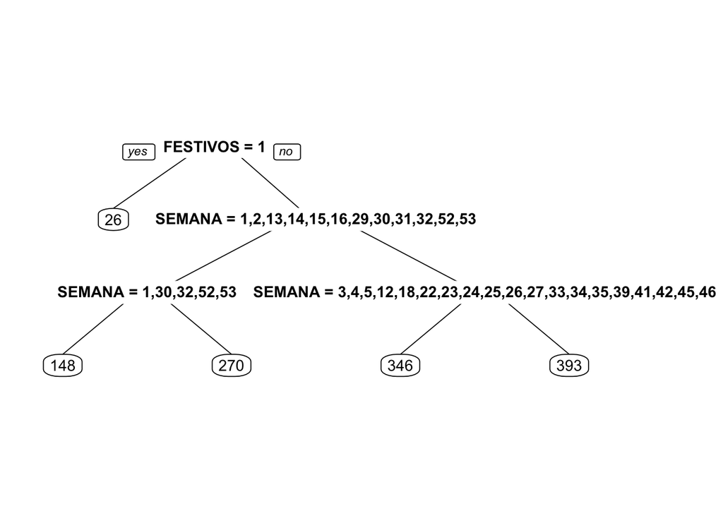

## 5.3 **Random Forest**

**Entrenamiento del modelo**

Se toma el modelo mas simple, a partir de este se realizara una búsqueda tipo grid search de los hiper parámetros óptimos, mediante el uso de la librería Range. Se analizaron en total 792 modelos diferentes con variaciones en mtry, mínimo tamaño de muestras en el nodo, y tamaño de la muestra.

```r
set.seed(101)
rf_sd = randomForest(SOLO_DANOS ~ ., data = soloD_train)
rf_sd
```

```
##
## Call:
##  randomForest(formula = SOLO_DANOS ~ ., data = soloD_train)
##                Type of random forest: regression
##                      Number of trees: 500
## No. of variables tried at each split: 3
##
##           Mean of squared residuals: 3509.473
##                     % Var explained: 85.81
```

Inicialmente, observamos que la varianza explicada por el modelo es del 85,81 %.

**Este gráfico muestra el error vs. el número de árboles**

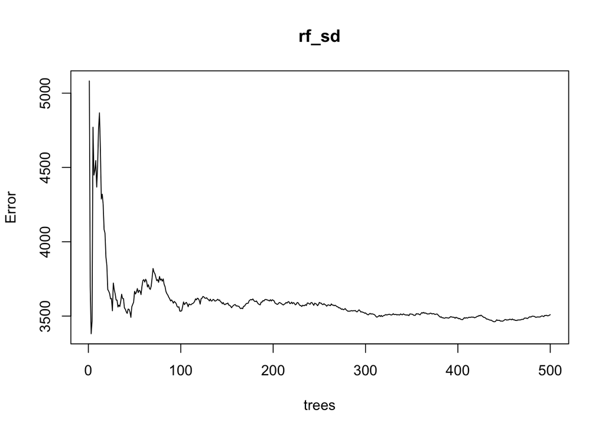

**Afinamiento del modelo Random Forest**

Se define la siguiente grilla de búsqueda:

```r
set.seed(101)
# hyperparameter grid search
hyper_grid_rf <- expand.grid(
  mtry       = seq(1, 9, by = 1),
  node_size  = seq(7, 50, by = 2),
  sampe_size = c(.55, .632, .70, .80),
  OOB_RMSE   = 0
)

# total number of combinations
#nrow(hyper_grid_rf)
```

Se utiliza la librería Ranger para la búsqueda de los mejores hyper parámetros:

```r
for(i in 1:nrow(hyper_grid_rf)) {

  # train model
  model <- ranger(
    formula         = SOLO_DANOS ~ .,
    data            = soloD_train,
    num.trees       = 500,
    mtry            = hyper_grid_rf$mtry[i],
    min.node.size   = hyper_grid_rf$node_size[i],
    sample.fraction = hyper_grid_rf$sampe_size[i],
    seed            = 101
  )

  # add OOB error to grid
  hyper_grid_rf$OOB_RMSE[i] <- sqrt(model$prediction.error)
}

hyper_grid_rf %>%
  dplyr::arrange(OOB_RMSE) %>%
  head(10)
```

|  | mtry | node_size | sampe_size | OOB_RMSE |
| --- | --- | --- | --- | --- |
| 1 | 8 | 7 | 0.800 | 53.11101 |
| 2 | 7 | 7 | 0.800 | 53.66984 |
| 3 | 8 | 7 | 0.700 | 53.71904 |
| 4 | 9 | 7 | 0.800 | 53.94701 |
| 5 | 8 | 7 | 0.632 | 53.95032 |
| 6 | 8 | 9 | 0.800 | 53.98363 |
| 7 | 8 | 9 | 0.700 | 54.39066 |
| 8 | 7 | 7 | 0.700 | 54.39638 |
| 9 | 9 | 7 | 0.700 | 54.41885 |
| 10 | 7 | 9 | 0.800 | 54.43151 |

Se ajusta el modelo con los mejores hyper parámetros obtenidos:

```r
set.seed(101)
mejorRandomforest <- randomForest(SOLO_DANOS ~., data = soloD_train, mtry = 8,
                                  nodesize = 7, ntree = 500,
                                  sampe_size= 0.8, importance = TRUE)
mejorRandomforest
```

```
##
## Call:
##  randomForest(formula = SOLO_DANOS ~ ., data = soloD_train, mtry = 8,      nodesize = 7, ntree = 500, sampe_size = 0.8, importance = TRUE)
##                Type of random forest: regression
##                      Number of trees: 500
## No. of variables tried at each split: 8
##
##           Mean of squared residuals: 3328.982
##                     % Var explained: 86.54
```

Con la función importance() se extrae la importancia de las variables.

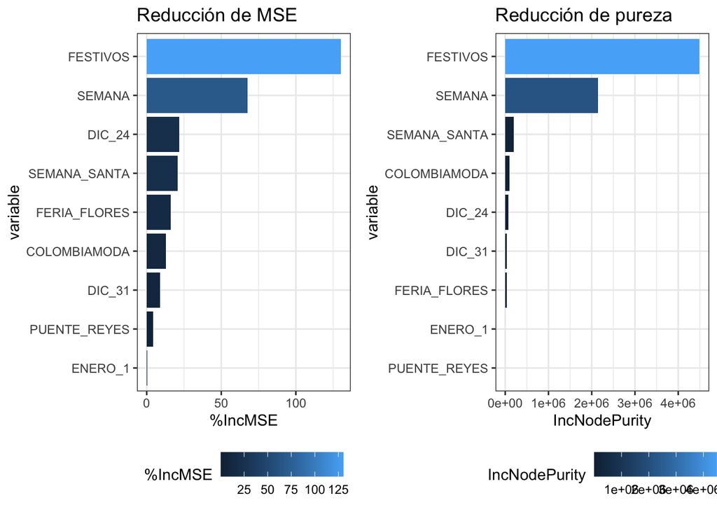

```r
library(tidyverse)
library(ggpubr)
importancia_pred <- as.data.frame(importance(mejorRandomforest, scale = TRUE))
importancia_pred <- rownames_to_column(importancia_pred, var = "variable")
p1 <- ggplot(data = importancia_pred, aes(x = reorder(variable, `%IncMSE`),
                                          y = `%IncMSE`,
                                          fill = `%IncMSE`)) +
    labs(x = "variable", title = "Reducción de MSE") +
    geom_col() +
    coord_flip() +
    theme_bw() +
    theme(legend.position = "bottom")

p2 <- ggplot(data = importancia_pred, aes(x = reorder(variable, IncNodePurity),
                                          y = IncNodePurity,
                                          fill = IncNodePurity)) +
    labs(x = "variable", title = "Reducción de pureza") +
    geom_col() +
    coord_flip() +
    theme_bw() +
    theme(legend.position = "bottom")
ggarrange(p1, p2)
```

**Métricas de bondad para modelo de Random Forest**

```r
pred_randomForest_t <- predict(mejorRandomforest, soloD_train)
pred_randomForest <- predict(mejorRandomforest, soloD_test)

dt_rf_1 <- data.frame(RMSE_Train = RMSE(pred_randomForest_t, soloD_train$SOLO_DANOS),
                    Rsquared_Train = R2(pred_randomForest_t, soloD_train$SOLO_DANOS),
                    RMSE_Test = RMSE(pred_randomForest, soloD_test$SOLO_DANOS),
                    Rsquared_Test = R2(pred_randomForest, soloD_test$SOLO_DANOS))


dt_rf_1
```

| RMSE_Train | Rsquared_Train | RMSE_Test | Rsquared_Test |
| --- | --- | --- | --- |
| 39.16793 | 0.9386766 | 47.72794 | 0.9018913 |

Observamos que los R-squared para entrenamiento y validación son mas altos en comparación con los modelos de regresión lineal y Árbol regresor. El RMSE presenta una variación aproximada de 21 %, a pesar de que no es la menor variación de los modelos expuestos, la variación con respecto al Rsquared es muy baja y por tal motivo se elige al RandomForest como mejor modelo.